# Exploration of Storms & severe weather events in the US

Stephane Hostiou

25/05/2020

## Abstract

Storms and other severe weather events can cause both public health and economic problems for communities and municipalities.  
Many severe events can result in fatalities, injuries, and property damage, and preventing such outcomes to the extent possible is a key concern.  
This document explores the impact, in the United States, of storms & severe weather events on :  
- human fatalities / injuries  
- the economy  
28/05/2020 : correcting an error on cost calculation (Billions not correctly affected)

## DATA PROCESSING

### Installing required libraries

```r
library(tidyverse)
library(varhandle)
```

### Setting the Working Directory

```r
## Setting Working directory
setwd("~/JohnsHopkins/JohnsHopkins/M05 - W04")

## Preparing a directory to store data
if (!file.exists("data"))
{
    dir.create("data")
}
```

### Collecting Data

Donwloading raw data from the course Web site  
https://d396qusza40orc.cloudfront.net/repdata%2Fdata%2FStormData.csv.bz2  
Raw data is stored in csv (comma separated file)

```r
fileUrl <- "https://d396qusza40orc.cloudfront.net/repdata%2Fdata%2FStormData.csv.bz2"
download.file(fileUrl, destfile="./data/rawstorm.bz2",method="libcurl")
```

Unzipping the storm data file to “data” disrectory by using read.csv and bzfile commands  
Unzipped data is transferred to the rawstorm dataframe

```r
rawstorm_df <- read.csv(bzfile("./data/rawstorm.bz2"),sep=',')
```

### QUESTION 1 : Across the United States, which types of events (EVTYPE Variable) are most harmful with respect to population health?

This question can be answered by focussing on data appearing in the “Fatalities” and “Injuries” columns of the dataset.  
Note that data stored in the dataset is reporting direct fatalities / direct injuries related to a specific storm event.  
Creating a subset to focus only on EVTYPE (type of events), Fatalities and injuries then building a pipe :  
grouping by EV_TYPE, Summarizing by sum of fatalities & injuries per event + arranging by descending order  
The resulting dataframe is stored in the “harmfulevent_df” variable

```r
harmfulevent_df <- select(rawstorm_df,EVTYPE,FATALITIES,INJURIES) %>% group_by(EVTYPE) %>%
  summarise(TOT_FATALITIES = sum(FATALITIES), TOT_INJURIES = sum(INJURIES)) %>% arrange(desc(TOT_FATALITIES), desc(TOT_INJURIES))
```

### QUESTION 2 : Across the United States, which types of events have the greatest economic consequences ?

This question can be answered by focussing on data contained in the “Damage” Columns.  
Damage data is encoded into 4 columns :  
- PROPDMG : Property Damage  
- PROPGMGEXP : Alphabetical characters used to signify magnitude include “K” for thousands, “M” for millions, and “B” for billions.  
- CROPDMG : Crop Damage  
- CROPDMGEXP : Alphabetical characters used to signify magnitude include “K” for thousands, “M” for millions, and “B” for billions.  
Creating a subset to focus only on EVTYPE (type of events) and damages thanks to a pipe.

```r
dmgevent_df <- select(rawstorm_df,EVTYPE,PROPDMG,PROPDMGEXP,CROPDMG,CROPDMGEXP) %>% group_by(EVTYPE)
```

Checking the consistency of the data stored in the PROPDMGEXP column.  
- Is there nas ?  
- are alphabetical characters conform to desciption : “k”,“M” or “B” ?

```r
sum(is.na(dmgevent_df$PROPDMG))
```

```
## [1] 0
```

```r
sum(is.na(dmgevent_df$PROPDMGEXP))
```

```
## [1] 0
```

Checking unique values content

```r
unique(dmgevent_df$PROPDMGEXP)
```

```
##  [1] K M   B m + 0 5 6 ? 4 2 3 h 7 H - 1 8
## Levels:  - ? + 0 1 2 3 4 5 6 7 8 B h H K m M
```

A bunch of values aren’ conform to description : “+, 0, 5, 6, h, H, etc.”  
Let’s determine the number of inconsistent records

```r
sort(summary(dmgevent_df$PROPDMGEXP))
```

```
##      -      8      h      3      4      6      +      7      H      m      ?
##      1      1      1      4      4      4      5      5      6      7      8
##      2      1      5      B      0      M      K
##     13     25     28     40    216  11330 424665 465934
```

It appears that the majority of the events are correctly encoded with values “”,“K” or “M”  
Rejecting the other values can be considered as part of the data cleanin process  
Checking the consistency of the data stored in the CROPDMGEXP column.  
- Is there nas ?  
- are alphabetical characters conform to desciption : “k”,“M” or “B” ?

```r
sum(is.na(dmgevent_df$CROPDMG))
```

```
## [1] 0
```

```r
sum(is.na(dmgevent_df$CROPDMGEXP))
```

```
## [1] 0
```

Checking unique values content

```r
unique(dmgevent_df$CROPDMGEXP)
```

```
## [1]   M K m B ? 0 k 2
## Levels:  ? 0 2 B k K m M
```

A bunch of values aren’ conform to description : “?”,“m”,“2” etc."  
Let’s determine the number of inconsistent records

```r
sort(summary(dmgevent_df$CROPDMGEXP))
```

```
##      2      m      ?      B      0      k      M      K
##      1      1      7      9     19     21   1994 281832 618413
```

It appears that the majority of the events are correctly encoded with values “”,“K” or “M”  
Rejecting the other values can be considered as part of the data cleanin process

### Data Cleaning

As a first step, data cleaning will consist in keeping correctly encoded values let’s define a vector of “correct amount characters” amount_char_v

```r
amount_char_v <- c("","K","M","B")
```

Extracting proper data from the dataframe using the previous vector

```r
dmgevent_clean_df <- dmgevent_df %>% filter(PROPDMGEXP %in% amount_char_v,CROPDMGEXP %in% amount_char_v)
# Correction factor levels
dmgevent_clean_df <- droplevels(dmgevent_clean_df)
```

### Calculating Cumulated Values

This operations requires to merge information contained on xxxDMG and xxxDMGEXP columns into numerical values  
ie if the value of xxxDMGEXP = K => then xxxDMG value will be multiplied by 1000

```r
dmgevent_clean_df <- dmgevent_clean_df %>%
  mutate(PROPDMGEXP_num =
    case_when(
      PROPDMGEXP=="" ~ 1,
      PROPDMGEXP=="K" ~ 1000,
      PROPDMGEXP=="M" ~ 1000000,
      PROPDMGEXP=="B" ~ 1000000000)
    )

dmgevent_clean_df <- dmgevent_clean_df %>%
  mutate(CROPDMGEXP_num =
           case_when(
             CROPDMGEXP=="" ~ 1,
             CROPDMGEXP=="K" ~ 1000,
             CROPDMGEXP=="M" ~ 1000000,
             CROPDMGEXP=="B" ~ 1000000000)
  )
```

Adding a column to the DF containing the total damages costs (Property + Crop damages)

```r
dmgevent_clean_df <- mutate(dmgevent_clean_df, TOTDMG = PROPDMG*PROPDMGEXP_num + CROPDMG*CROPDMGEXP_num)
```

Subsetting the DF in order to report total damage costs grouped by events and sorted in desc order

```r
dmgcost_df <- select(dmgevent_clean_df,EVTYPE,TOTDMG) %>% group_by(EVTYPE) %>% summarise(TOT_DAM_COST = sum(TOTDMG)) %>%
  arrange(desc(TOT_DAM_COST))
```

## RESULTS

### Most Harmful Event

Focussing on the 6 most impacting events in terms of total number of deaths and injuries, it appears that the most harmful  
event is TORNADO

```r
head(harmfulevent_df)
```

```
## # A tibble: 6 x 3
##   EVTYPE         TOT_FATALITIES TOT_INJURIES
##   <fct>                   <dbl>        <dbl>
## 1 TORNADO                  5633        91346
## 2 EXCESSIVE HEAT           1903         6525
## 3 FLASH FLOOD               978         1777
## 4 HEAT                      937         2100
## 5 LIGHTNING                 816         5230
## 6 TSTM WIND                 504         6957
```

This observation can be confirmed by a plot showing the 6 most Fatal events  
Note that in order to arrange the plot in descending order, the factor levels need to be updated thanks to a pipe

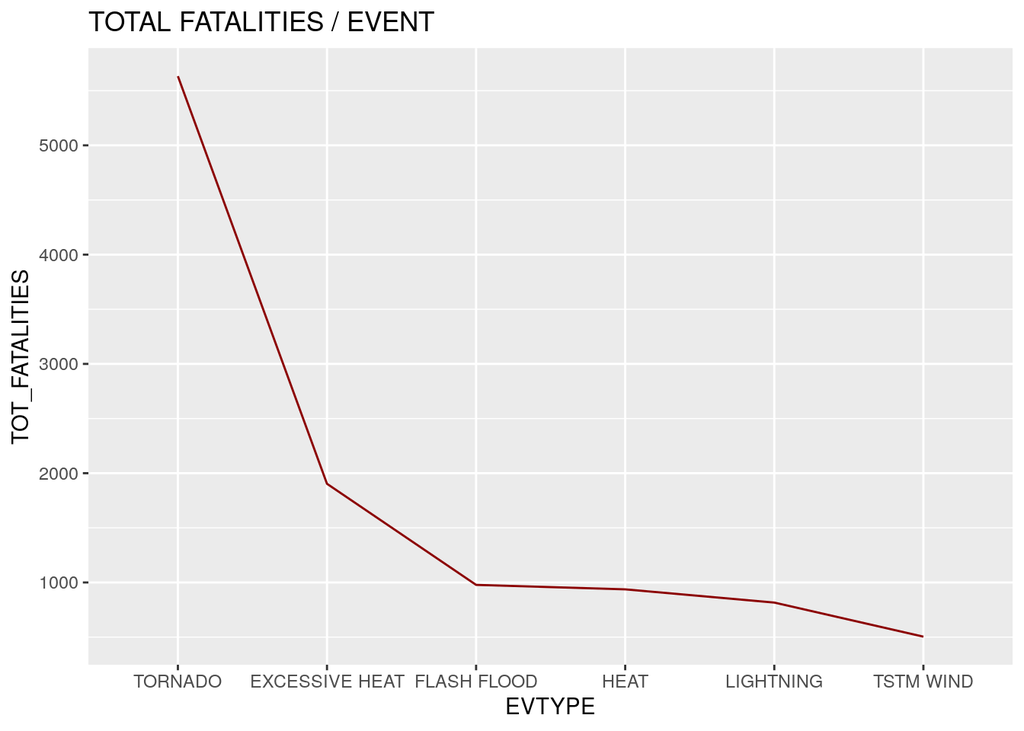

```r
head(harmfulevent_df) %>% mutate(EVTYPE=factor(EVTYPE, levels=EVTYPE)) %>%
ggplot(aes(EVTYPE, group=1)) + geom_line(aes(y=TOT_FATALITIES),color="darkred") +
  labs(title = "TOTAL FATALITIES / EVENT")
```

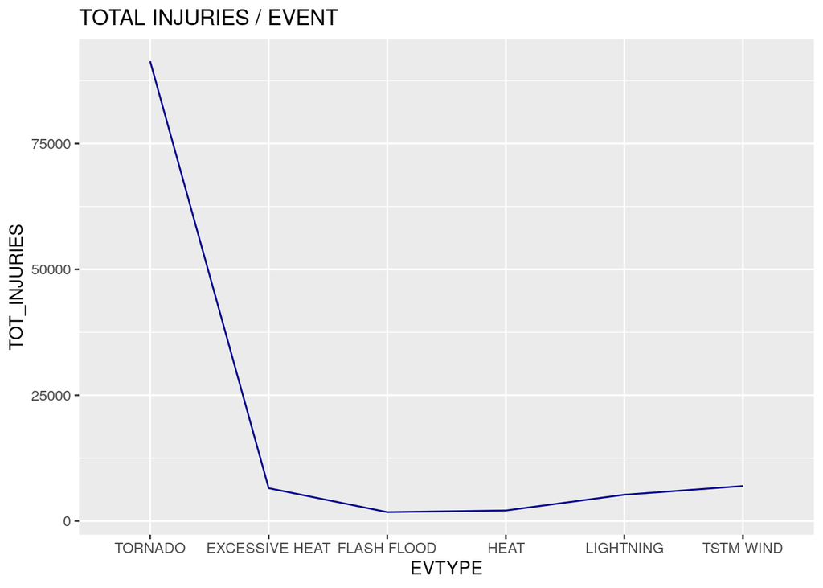

```r
head(harmfulevent_df) %>% mutate(EVTYPE=factor(EVTYPE, levels=EVTYPE)) %>%
  ggplot(aes(EVTYPE, group=1)) + geom_line(aes(y=TOT_INJURIES),color="darkblue") +
  labs(title = "TOTAL INJURIES / EVENT")
```

### Event having the greatest economical impact

Focussing on the 6 most impacting events in terms of economical aspect, it appears that the most significant event is Flood.

```r
head(dmgcost_df)
```

```
## # A tibble: 6 x 2
##   EVTYPE            TOT_DAM_COST
##   <fct>                    <dbl>
## 1 FLOOD             150319678257
## 2 HURRICANE/TYPHOON  71913712800
## 3 TORNADO            57290435593
## 4 STORM SURGE        43323541000
## 5 HAIL               18727703230
## 6 FLASH FLOOD        17561538817
```

It appears that the event having, by far, the greatest economical impact is Flood  
Let’s confirm this observation with a plot

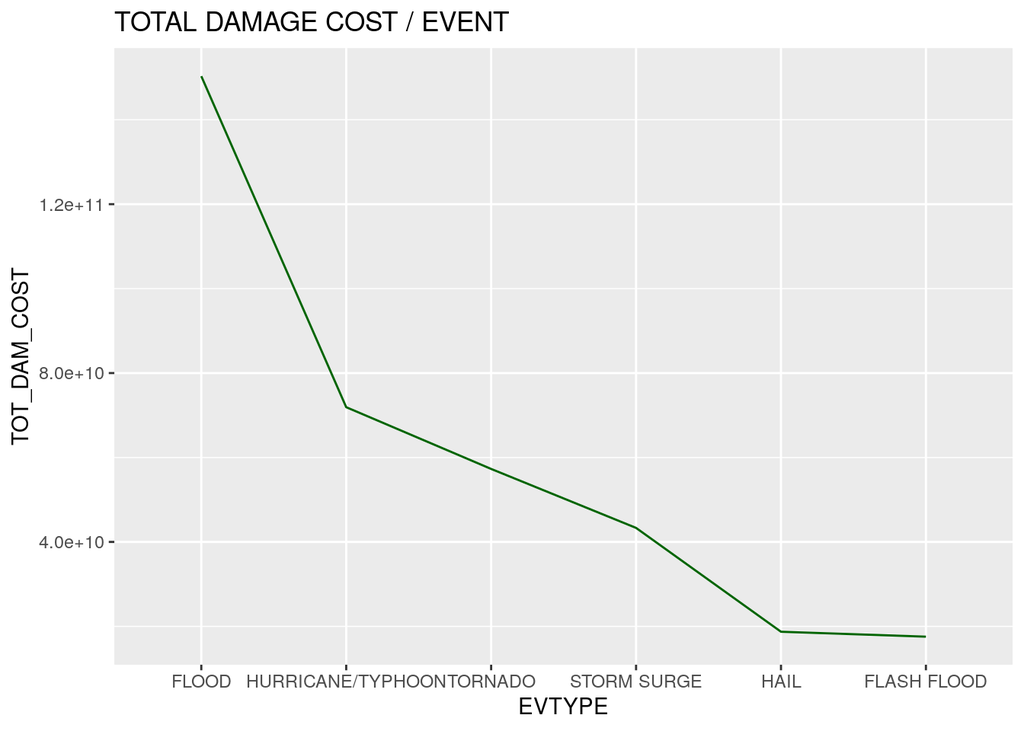

```r
head(dmgcost_df) %>% mutate(EVTYPE=factor(EVTYPE, levels=EVTYPE)) %>%
  ggplot(aes(EVTYPE, group=1)) + geom_line(aes(y=TOT_DAM_COST),color="darkgreen") +
  labs(title = "TOTAL DAMAGE COST / EVENT")
```